# BMIN503 Final Project: Subconscious Bias in Pregnancy: Unraveling the Influential Factors within a Healthcare System

## 1 Overview

Research indicates that subconscious bias significantly impacts the communication and treatment of Black women by healthcare professionals, contributing to subsequent disparities in maternal health. Black women encounter heightened communication challenges in perinatal healthcare compared to White women. Even when accounting for clinical factors, Black women are less likely to undergo labor induction, receive regular cervical examinations, and more likely to undergo cesarean delivery under general anesthesia (1). These disparities in communication and treatment result in Black women facing a two-fold higher risk of severe maternal morbidity and a threefold higher risk of pregnancy-related death than their White counterparts (1). The primary objective of this project is to investigate healthcare system factors contributing to bias in pregnancy and identify potential areas for improvement within the healthcare system.

## 2 Introduction

The United States grapples with persistent racial inequities and disparities in maternal health. In Philadelphia, non-Hispanic Black women face a staggering fourfold higher likelihood of pregnancy-related deaths compared to non-Hispanic White women. Despite the city being home to distinguished medical centers/hospitals, the 2020 Improving Outcomes: Maternal Mortality in Philadelphia report reveals pregnancy-related death rates surpass the national average (2). From 2013-2018, non-Hispanic Black women accounted for 43% of births but sadly represented 73% of pregnancy-related deaths (2). In contrast, non-Hispanic White women accounted for 26% of births and 19% of pregnancy-related deaths (3). These stark racial inequities in maternal health, particularly pregnancy-related deaths, are undeniable in Philadelphia. There are various factors which contribute to this crisis including subconscious and implicit bias.

For my project, I utilized a pregnancy intention dataset, encompassing a cohort of pre-covid births at two PENN affiliated hospitals, HUP and PAH. For background, as part of routine practice, every patient attending a new OB or GYN consultation is asked about the intentionality of the pregnancy—whether it is intended or unintended, desired, or undesired. To build the cohort, the study team used detailed information which was abstracted from maternal electronic medical records on demographic characteristics, reproductive and prenatal history, and labor and delivery summaries. The primary focus of my study centers on whether an individual is asked the pregnancy desire question, considering a positive or “yes” response regardless of the specific nature of the desire. In this context, the analysis does not delve into the specifics of whether the pregnancy is desired or not. For the purposes of my project, I extracted variables of interest including patient demographics and patient level characteristics.

## 4 Installing packages that I will need throughout.

```r
#Load common packages that will be used

# install.packages("tidyverse")
# install.packages("dplyr")
# install.packages("gtsummary")
# install.packages("arrow")
# install.packages("ggplot")
# install.packages("modelsummary")
# install.packages("modelr")
# install.packages("yardstick")
# install.packages("cowplot")
# install.packages("vip")
# install.packages("tidymodels")
# install.packages("scales")
# install.packages("randomForest")
# install.packages("kernlab")
# install.packages("glmnet")
# install.packages("dotwhisker")
# install.packages("gridExtra")
```

## 5 Loading packages that I will need throughout.

```r
library(haven)
library(tidyverse)
library(dplyr)
library(gtsummary)
library(arrow)
library(ggplot2)
library(modelsummary)
library(modelr)
library(yardstick)
library(cowplot)
library(vip)
library(tidymodels)
library(RColorBrewer)
library(scales)
library(randomForest)
library(kernlab)
library(glmnet)
library(dotwhisker)
library(gridExtra)
```

## 6 First I begin by reading in the dataset I will work with. The dataset is originally in a SAS program so I will need to use the haven package for use in R.

```r
#Set WD to path for dataset
# install.packages("haven")
# library(haven)

pregintent_dataset <- read_sas("Q:/Mary Sammel/OBGYN/Arden McCallister/PregnancyIntention_Abernathy/data/Derived/goba_research3.sas7bdat")
```

## 7 Initial Data Manipulation

Firstly, I want to create a summary table but will need to manipulate the data set. The original data set has 93 variables but for this analysis I am only interested in 10 variables. I create a new data set which is a subset from the original data set.

```r
# Select variables of interest/subset
# Specify the variables of interest
pregintent_vars <- c("MG_Responded_Desire", "MF_Race_Cat", "MF_Age", "MF_ethnicity", "MF_Insurance_Cat", "MF_Entry_Obese", "MF_Entry_Encounter_Type", "HOSPITAL", "MG_GA", "MG_ER_Utilization" )

# Subset the data set to include only variables of interest. New dataset for analysis--preg_desire
preg_desire <- pregintent_dataset |>
  select(all_of(pregintent_vars))
```

## 8 Additonal Data Manipulation and Transformation

There is additional data manipulation needed. I will use the dplyr package, specifically the mutate function to create new variables based on variables in the original data set.I also convert the variables to a factor with specific levels and labels. This will be helpful when creating plots for data visualization later on.

```r
#Create new variables using mutate. Table function is useful for understanding the distribution of values in a categorical variable.

#RACE CATEGORY IS ACTUALLY FOR BLACK PARTICIPANTS

preg_desire <- mutate(preg_desire, MG_Responded_Desire = factor(MG_Responded_Desire, levels = c(0,1),
                    labels = c("No", "Yes")))

preg_desire <- mutate(preg_desire, MF_Age = factor(MF_Age, levels = c(0,1,2,3,4,5),
                    labels = c("19 and Under", "20-24 years", "25-29 years", "30-34 years", "35-39 years", "40-44 years")))

preg_desire <- mutate(preg_desire, MF_Race_Cat = factor(MF_Race_Cat, levels = c(0,1),
                    labels = c("White/Other", "Black")))

preg_desire <- mutate(preg_desire, MF_ethnicity = factor(MF_ethnicity, levels = c(0,1),
                    labels = c("Non-Hispanic", "Hispanic")))

preg_desire <- mutate(preg_desire, MF_Entry_Obese = factor(MF_Entry_Obese, levels = c(0,1),
                    labels = c("Not Obese", "Obese")))

preg_desire <- mutate(preg_desire, MF_Insurance_Cat = factor(MF_Insurance_Cat, levels = c(0,1),
                    labels = c("Private", "Public/Uninsured")))

preg_desire <- mutate(preg_desire, MF_Entry_Encounter_Type = factor(MF_Entry_Encounter_Type, levels = c("Hospital Encounter" , "Office Visit", "Procedure"),
                    labels = c("Hospital Encounter" , "Office Visit", "Procedure")))

preg_desire <- mutate(preg_desire, HOSPITAL = factor(HOSPITAL, levels = c("HUP","PAH"),
                    labels = c("HUP", "PAH")))

preg_desire <- mutate(preg_desire, MG_GA = factor(MG_GA, levels = c(0,1),
                    labels = c("Less Than 24Weeks", "Greater than 24Weeks")))

preg_desire <- mutate(preg_desire, MG_ER_Utilization = factor(MG_ER_Utilization,      levels = c(0,1),
                    labels = c("No ER Utilization ", "ER Utilization")))
```

## 9 Summary Table Including Variables of Interest

After cleaning and manipulating the data, I create a table 1 or summary table of the new subsetted dataset “preg_desire”. This summary table shows all the variables in the “preg_desire” data set which I will use primarily throughout analysis.

```r
preg_desire |> tbl_summary()
```

| **Characteristic** | **N = 9,672**<sup>1</sup> |
| --- | --- |
| MG_Responded_Desire | 3,149 (33%) |
| MF_Race_Cat |  |
| White/Other | 4,619 (52%) |
| Black | 4,318 (48%) |
| Unknown | 735 |
| MF_Age |  |
| 19 and Under | 284 (3.2%) |
| 20-24 years | 1,174 (13%) |
| 25-29 years | 2,169 (24%) |
| 30-34 years | 3,210 (36%) |
| 35-39 years | 1,786 (20%) |
| 40-44 years | 358 (4.0%) |
| Unknown | 691 |
| MF_ethnicity |  |
| Non-Hispanic | 8,817 (92%) |
| Hispanic | 771 (8.0%) |
| Unknown | 84 |
| MF_Insurance_Cat |  |
| Private | 4,786 (52%) |
| Public/Uninsured | 4,379 (48%) |
| Unknown | 507 |
| MF_Entry_Obese |  |
| Not Obese | 5,509 (68%) |
| Obese | 2,543 (32%) |
| Unknown | 1,620 |
| MF_Entry_Encounter_Type |  |
| Hospital Encounter | 864 (9.6%) |
| Office Visit | 6,366 (71%) |
| Procedure | 1,751 (19%) |
| Unknown | 691 |
| HOSPITAL |  |
| HUP | 4,387 (45%) |
| PAH | 5,285 (55%) |
| MG_GA |  |
| Less Than 24Weeks | 59 (0.6%) |
| Greater than 24Weeks | 9,582 (99%) |
| Unknown | 31 |
| MG_ER_Utilization |  |
| No ER Utilization | 5,550 (57%) |
| ER Utilization | 4,122 (43%) |

<sup>1</sup> n (%)

## 10 Crude Analysis

Running a crude analysis to examine the variables of interest in relation to the outcome variable. This will provide a preliminary view of the data.The outcome variable is MG_Responded_Desire which captures whether there is a response to the question “Do you desire this pregnancy?”.

For this first bivariate analysis we se that there is a statistically significant relationship between a patients age and whether they are asked the pregnancy desire question.

```r
# # Run Crude Analysis

Age.Desire <-
  preg_desire |>
  select(MF_Age,MG_Responded_Desire) |>
  tbl_summary(
    by = MG_Responded_Desire, percent = "row",
    label = list(MF_Age ~ "Patient Age"),
    statistic = list(all_continuous() ~ "{mean} ({sd})"),
    digits = list(MF_Age ~ c(0,1,2,3,4,5))
  ) |>
add_p(test = everything() ~ "chisq.test") #adding the p-value
Age.Desire
```

| **Characteristic** | **No**, N = 6,523<sup>1</sup> | **Yes**, N = 3,149<sup>1</sup> | **p-value**<sup>2</sup> |
| --- | --- | --- | --- |
| Patient Age |  |  | <0.001 |
| 19 and Under | 118 (41.5%) | 166 (58.5%) |  |
| 20-24 years | 534 (45.5%) | 640 (54.5%) |  |
| 25-29 years | 1,281 (59.1%) | 888 (40.9%) |  |
| 30-34 years | 2,328 (72.5%) | 882 (27.5%) |  |
| 35-39 years | 1,367 (76.5%) | 419 (23.5%) |  |
| 40-44 years | 260 (72.6%) | 98 (27.4%) |  |
| Unknown | 635 | 56 |  |

<sup>1</sup> n (%)  
<sup>2</sup> Pearson’s Chi-squared test

This next bivariate analysis shows that there is a statistically significant relationship between a patients’ race and wheter they are asked the pregnancy desire question.

```r
#Race x Responded Desire
Race.Desire<-
  preg_desire |>
  select(MF_Race_Cat,MG_Responded_Desire) |>
  tbl_summary(
    by = MG_Responded_Desire, percent = "row",
    label = list(MF_Race_Cat ~ "Race"),
    statistic = list(all_continuous() ~ "{mean} ({sd})"),
    digits = list(MF_Race_Cat ~ c(0,1))
  ) |>
add_p(test = everything() ~ "chisq.test") #adding the p-value
Race.Desire
```

| **Characteristic** | **No**, N = 6,523<sup>1</sup> | **Yes**, N = 3,149<sup>1</sup> | **p-value**<sup>2</sup> |
| --- | --- | --- | --- |
| Race |  |  | <0.001 |
| White/Other | 3,764 (81.5%) | 855 (18.5%) |  |
| Black | 2,228 (51.6%) | 2,090 (48.4%) |  |
| Unknown | 531 | 204 |  |

<sup>1</sup> n (%)  
<sup>2</sup> Pearson’s Chi-squared test

We see in this bivariate analysis that there is statistically significant relationship between ethnicity and whether a patient is asked the pregnancy desire question, though it is not as strong of a significance as the other relationships above.

```r
#Ethnicity x Responded Desire
Ethnicity.Desire<-
  preg_desire |>
  select(MF_ethnicity,MG_Responded_Desire) |>
  tbl_summary(
    by = MG_Responded_Desire, percent = "row",
    label = list(MF_ethnicity ~ "Ethnicity"),
    statistic = list(all_continuous() ~ "{mean} ({sd})"),
    digits = list(MF_ethnicity ~ c(0,1))
  ) |>
add_p(test = everything() ~ "chisq.test") #adding the p-value
Ethnicity.Desire
```

| **Characteristic** | **No**, N = 6,523<sup>1</sup> | **Yes**, N = 3,149<sup>1</sup> | **p-value**<sup>2</sup> |
| --- | --- | --- | --- |
| Ethnicity |  |  | 0.021 |
| Non-Hispanic | 5,914 (67.1%) | 2,903 (32.9%) |  |
| Hispanic | 549 (71.2%) | 222 (28.8%) |  |
| Unknown | 60 | 24 |  |

<sup>1</sup> n (%)  
<sup>2</sup> Pearson’s Chi-squared test

Interestingly, in this bivariate relationship we see that there is a statistically significant relationship between a patients’ obesity status and whether they are asked the pregnancy desire question.

```r
#Obesity x Responded Desire
Obesity.Desire<-
  preg_desire |>
  select(MF_Entry_Obese,MG_Responded_Desire) |>
  tbl_summary(
    by = MG_Responded_Desire, percent = "row",
    label = list(MF_Entry_Obese ~ "Obese Status"),
    statistic = list(all_continuous() ~ "{mean} ({sd})"),
    digits = list(MF_Entry_Obese ~ c(0,1))
  ) |>
add_p(test = everything() ~ "chisq.test") #adding the p-value
Obesity.Desire
```

| **Characteristic** | **No**, N = 6,523<sup>1</sup> | **Yes**, N = 3,149<sup>1</sup> | **p-value**<sup>2</sup> |
| --- | --- | --- | --- |
| Obese Status |  |  | <0.001 |
| Not Obese | 3,697 (67.1%) | 1,812 (32.9%) |  |
| Obese | 1,314 (51.7%) | 1,229 (48.3%) |  |
| Unknown | 1,512 | 108 |  |

<sup>1</sup> n (%)  
<sup>2</sup> Pearson’s Chi-squared test

The relationship between a patients’ insurance status or type and whether they are asked the pregnancy desire question is statistically significant.

```r
#Insurance x Responded Desire
Insurance.Desire<-
  preg_desire |>
  select(MF_Insurance_Cat,MG_Responded_Desire) |>
  tbl_summary(
    by = MG_Responded_Desire, percent = "row",
    label = list(MF_Insurance_Cat ~ "Insurance Status"),
    statistic = list(all_continuous() ~ "{mean} ({sd})"),
    digits = list(MF_Insurance_Cat ~ c(0,1))
  ) |>
add_p(test = everything() ~ "chisq.test") #adding the p-value
Insurance.Desire
```

| **Characteristic** | **No**, N = 6,523<sup>1</sup> | **Yes**, N = 3,149<sup>1</sup> | **p-value**<sup>2</sup> |
| --- | --- | --- | --- |
| Insurance Status |  |  | <0.001 |
| Private | 3,738 (78.1%) | 1,048 (21.9%) |  |
| Public/Uninsured | 2,333 (53.3%) | 2,046 (46.7%) |  |
| Unknown | 452 | 55 |  |

<sup>1</sup> n (%)  
<sup>2</sup> Pearson’s Chi-squared test

We also see a statistically significant relationship between the encounter type and whether a patient is asked the pregnancy desire question.

```r
#Encounter Type x Responded Desire
Encounter_type.Desire<-
  preg_desire |>
  select(MF_Entry_Encounter_Type,MG_Responded_Desire) |>
  tbl_summary(
    by = MG_Responded_Desire, percent = "row",
    label = list(MF_Entry_Encounter_Type ~ "Encounter Type"),
    statistic = list(all_continuous() ~ "{mean} ({sd})"),
    digits = list(MF_Entry_Encounter_Type ~ c(0,1))
  ) |>
add_p(test = everything() ~ "chisq.test") #adding the p-value
Encounter_type.Desire
```

| **Characteristic** | **No**, N = 6,523<sup>1</sup> | **Yes**, N = 3,149<sup>1</sup> | **p-value**<sup>2</sup> |
| --- | --- | --- | --- |
| Encounter Type |  |  | <0.001 |
| Hospital Encounter | 704 (81.5%) | 160 (18.5%) |  |
| Office Visit | 4,114 (64.6%) | 2,252 (35.4%) |  |
| Procedure | 1,070 (61.1%) | 681 (38.9%) |  |
| Unknown | 635 | 56 |  |

<sup>1</sup> n (%)  
<sup>2</sup> Pearson’s Chi-squared test

Surprisingly, we see that there is a statistically significant relationship between hospital location and whether a patient is asked the pregnancy desire question. We see that patients at HUP are more than four times likely to be asked the pregnancy desire question compared to PAH.

```r
#Hospital x Responded Desire
HOSPITAL.Desire<-
  preg_desire |>
  select(HOSPITAL,MG_Responded_Desire) |>
  tbl_summary(
    by = MG_Responded_Desire, percent = "row",
    label = list(HOSPITAL ~ "Hospital Location"),
    statistic = list(all_continuous() ~ "{mean} ({sd})"),
    digits = list(HOSPITAL ~ c(0,1))
  ) |>
add_p(test = everything() ~ "chisq.test") #adding the p-value
HOSPITAL.Desire
```

| **Characteristic** | **No**, N = 6,523<sup>1</sup> | **Yes**, N = 3,149<sup>1</sup> | **p-value**<sup>2</sup> |
| --- | --- | --- | --- |
| Hospital Location |  |  | <0.001 |
| HUP | 1,949 (44.4%) | 2,438 (55.6%) |  |
| PAH | 4,574 (86.5%) | 711 (13.5%) |  |

<sup>1</sup> n (%)  
<sup>2</sup> Pearson’s Chi-squared test

There is no statistically significant relationship between gestational age and whether a patient is asked the pregnancy desire question. However, it is intriguing to note that patients at 24 weeks of gestation or beyond are still being asked the pregnancy desire question at rates comparable to those who are less than 24 weeks gestation. This observation is noteworthy considering that in the state of Pennsylvania, there are limited options for patients who reach 24 weeks gestation, typically involving carrying the pregnancy to term. The motivation behind posing this question to patients at 24 weeks gestation or more raises interesting questions and warrants further exploration (not done in this analysis).

```r
#Gestation Weeks x Responded Desire
MG_GA.Desire<-
  preg_desire |>
  select(MG_GA,MG_Responded_Desire) |>
  tbl_summary(
    by = MG_Responded_Desire, percent = "row",
    label = list(MG_GA ~ "Gestational Age"),
    statistic = list(all_continuous() ~ "{mean} ({sd})"),
    digits = list(MG_GA ~ c(0,1))
  ) |>
add_p(test = everything() ~ "chisq.test") #adding the p-value
MG_GA.Desire
```

| **Characteristic** | **No**, N = 6,523<sup>1</sup> | **Yes**, N = 3,149<sup>1</sup> | **p-value**<sup>2</sup> |
| --- | --- | --- | --- |
| Gestational Age |  |  | >0.9 |
| Less Than 24Weeks | 39 (66.1%) | 20 (33.9%) |  |
| Greater than 24Weeks | 6,454 (67.4%) | 3,128 (32.6%) |  |
| Unknown | 30 | 1 |  |

<sup>1</sup> n (%)  
<sup>2</sup> Pearson’s Chi-squared test

There is a statistically significant relationship between ER utilization and whether a patient is asked the pregnancy desire question.

```r
#ER Utilization  x Responded Desire
ER_Utilization.Desire<-
  preg_desire |>
  select(MG_ER_Utilization,MG_Responded_Desire) |>
  tbl_summary(
    by = MG_Responded_Desire, percent = "row",
    label = list(MG_ER_Utilization ~ "ER Utilization"),
    statistic = list(all_continuous() ~ "{mean} ({sd})"),
    digits = list(MG_ER_Utilization ~ c(0,1))
  ) |>
add_p(test = everything() ~ "chisq.test") #adding the p-value
ER_Utilization.Desire
```

| **Characteristic** | **No**, N = 6,523<sup>1</sup> | **Yes**, N = 3,149<sup>1</sup> | **p-value**<sup>2</sup> |
| --- | --- | --- | --- |
| ER Utilization |  |  | <0.001 |
| No ER Utilization | 3,498 (63.0%) | 2,052 (37.0%) |  |
| ER Utilization | 3,025 (73.4%) | 1,097 (26.6%) |  |

<sup>1</sup> n (%)  
<sup>2</sup> Pearson’s Chi-squared test

## 11 Creating Plots for Data Visualizations of The Crude Analysis

Pregnancy Desire Asked by Age Categories

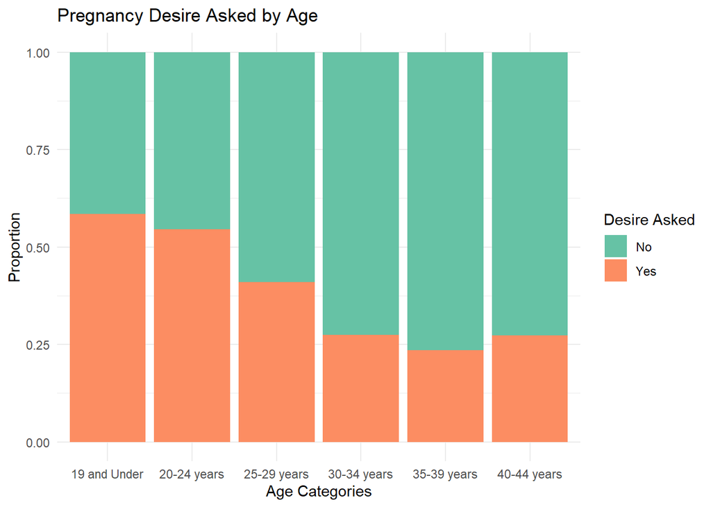

```r
#Visualizations
#Bar Chart (continuous x binary) Age x MG_Responded_Desire
my_colors <- brewer.pal(3, "Set2")
# Define a color palette

preg_desire |>
  filter(!is.na(MF_Age)) |>
  ggplot(aes(MF_Age, fill = MG_Responded_Desire)) +
  geom_bar(position = "fill") +
  labs(
    x = "Age Categories",
    y = "Proportion",
    fill = "Responded Desire",
    title = "Pregnancy Desire Asked by Age"
  ) +
  scale_fill_manual(
    name = "Desire Asked",
    values = my_colors,
    labels = c("No", "Yes"),
    breaks = c("No", "Yes")
  ) +
  theme_minimal()
```

Pregnancy Desire Asked by Race Categories

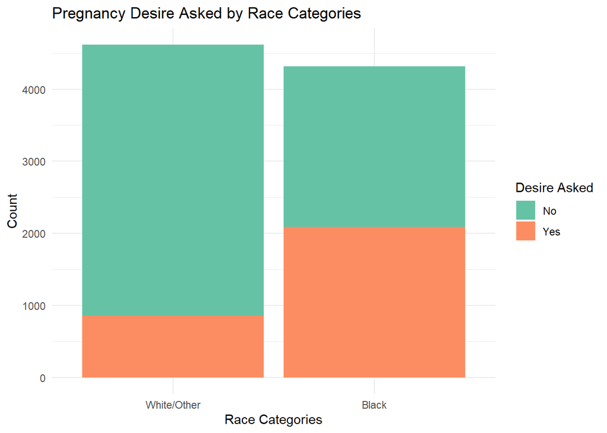

```r
#Visualiztions
#Bar Graph (categorical/nominal x binary) Race x MG_Responded_Desire

preg_desire |>
  filter(!is.na(MF_Race_Cat)) |>
  ggplot(aes(x = MF_Race_Cat, fill = MG_Responded_Desire)) +
  geom_bar() +
  labs(
    x = "Race Categories",
    y = "Count",
    fill = "Responded Desire",
    title = "Pregnancy Desire Asked by Race Categories"
  ) +
  scale_fill_manual(
    name = "Desire Asked",
    values = brewer.pal(3, "Set2"),  # Use a better color palette
    labels = c("No", "Yes"),
    breaks = c("No", "Yes")
  ) +
  theme_minimal()
```

Pregnancy Desire Asked by Ethnicity

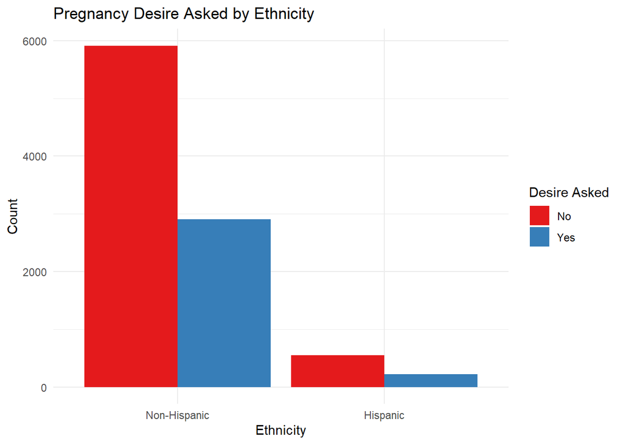

```r
#Visualiztions
#Bar Graph (categorical/nominal x binary) Ethnicity x MG_Responded_Desire


my_colors <- brewer.pal(2, "Set1")

# Create the ggplot with title, better legend, and color palette
my_colors <- brewer.pal(2, "Set1")

# Create the ggplot with title, informative legend, and color palette
preg_desire |>
  filter(!is.na(MF_ethnicity)) |>
  ggplot(aes(x = MF_ethnicity, fill = MG_Responded_Desire)) +
  geom_bar(position = "dodge") +
  labs(
    x = "Ethnicity",
    y = "Count",
    fill = "Responded Desire",
    title = "Pregnancy Desire Asked by Ethnicity"
  ) +
  scale_fill_manual(
    name = "Desire Asked",
    values = my_colors,
    labels = c("No", "Yes")
  ) +
  theme_minimal()
```

Pregnancy Desire Asked by Obese Status

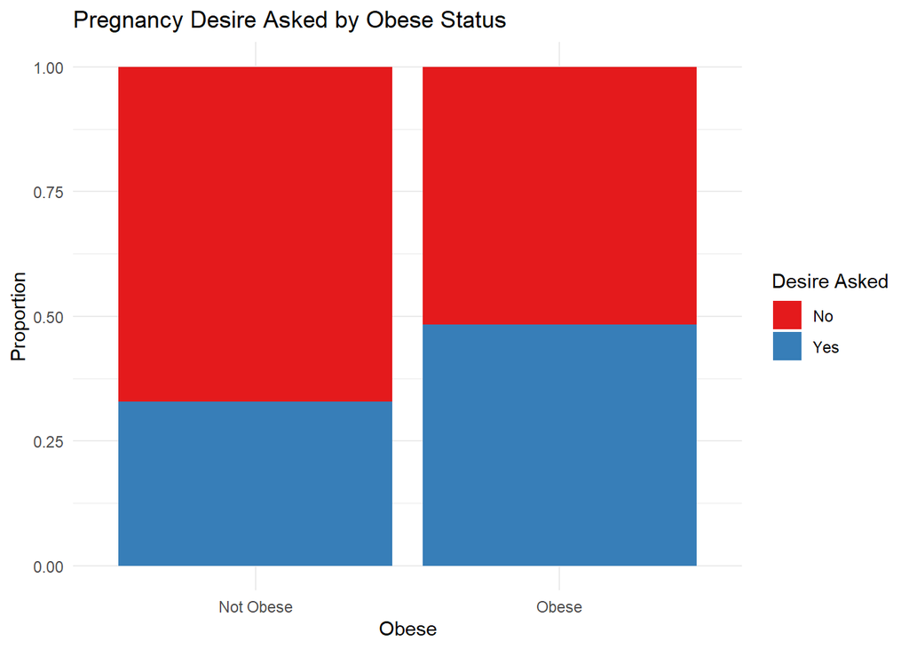

```r
#Visualiztions
#Bar Chart (binaryxbinary) Obesity x MG_Responded_Desire **use this code for race, insurance to show percentages**


my_colors <- brewer.pal(2, "Set1")

# Create the ggplot with title, informative legend, and color palette
preg_desire |>
  filter(!is.na(MF_Entry_Obese)) |>
  ggplot(aes(MF_Entry_Obese, fill = MG_Responded_Desire)) +
  geom_bar(position = "fill") +
  labs(
    x = "Obese",
    y = "Proportion",
    fill = "Responded Desire",
    title = "Pregnancy Desire Asked by Obese Status"
  ) +
  scale_fill_manual(
    name = "Desire Asked",
    values = my_colors,
    labels = c("No", "Yes"),
    breaks = c("No", "Yes")
  ) +
  theme_minimal()
```

Pregnancy Desire Asked by Insurance Category

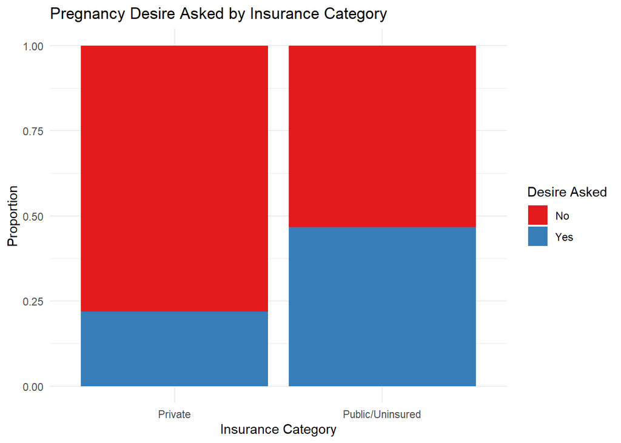

```r
#Barplot (binaryxbinary) Insurance x MG_Responded_Desire


my_colors <- brewer.pal(2, "Set1")


# Create the ggplot with title, informative legend, and color palette
preg_desire |>
  filter(!is.na(MF_Insurance_Cat)) |>
  ggplot(aes(x = MF_Insurance_Cat, fill = MG_Responded_Desire)) +
  geom_bar(position = "fill") +
  labs(
    x = "Insurance Category",
    y = "Proportion",
    fill = "Responded Desire",
    title = "Pregnancy Desire Asked by Insurance Category"
  ) +
  scale_fill_manual(
    name = "Desire Asked",
    values = brewer.pal(2, "Set1"),
    labels = c("No", "Yes"),
    breaks = c("No", "Yes")
  ) +
  theme_minimal()
```

Pregnancy Desire Asked by Encounter Type

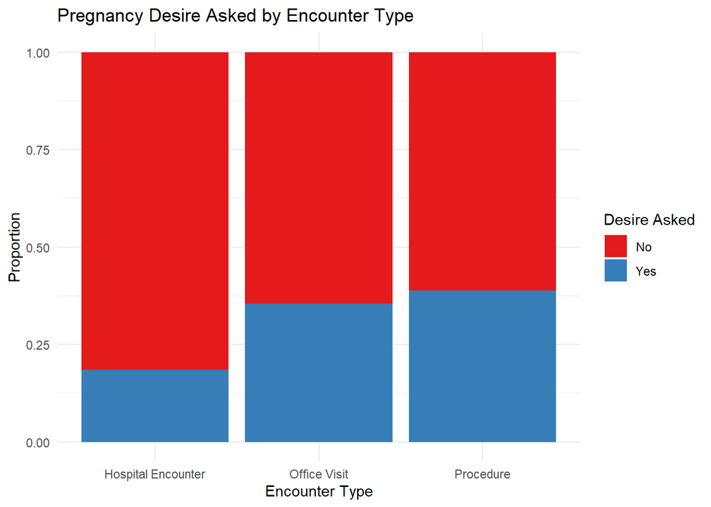

```r
#Encounter_type.Desire x MG_Responded_Desire

my_colors <- brewer.pal(2, "Set1")


# Create the ggplot with title, informative legend, and color palette
preg_desire |>
  filter(MF_Entry_Encounter_Type != "") |>
  ggplot(
       aes(MF_Entry_Encounter_Type, fill = MG_Responded_Desire)) +
  geom_bar(position = "fill") +
  labs(
    x = "Encounter Type",
    y = "Proportion",
    fill = "Responded Desire",
    title = "Pregnancy Desire Asked by Encounter Type"
  ) +
  scale_fill_manual(
    name = "Desire Asked",
    values = my_colors,
    labels = c("No", "Yes"),
    breaks = c("No", "Yes")
  ) +
  theme_minimal()
```

Pregnancy Desire Asked Desire by Hospital Location

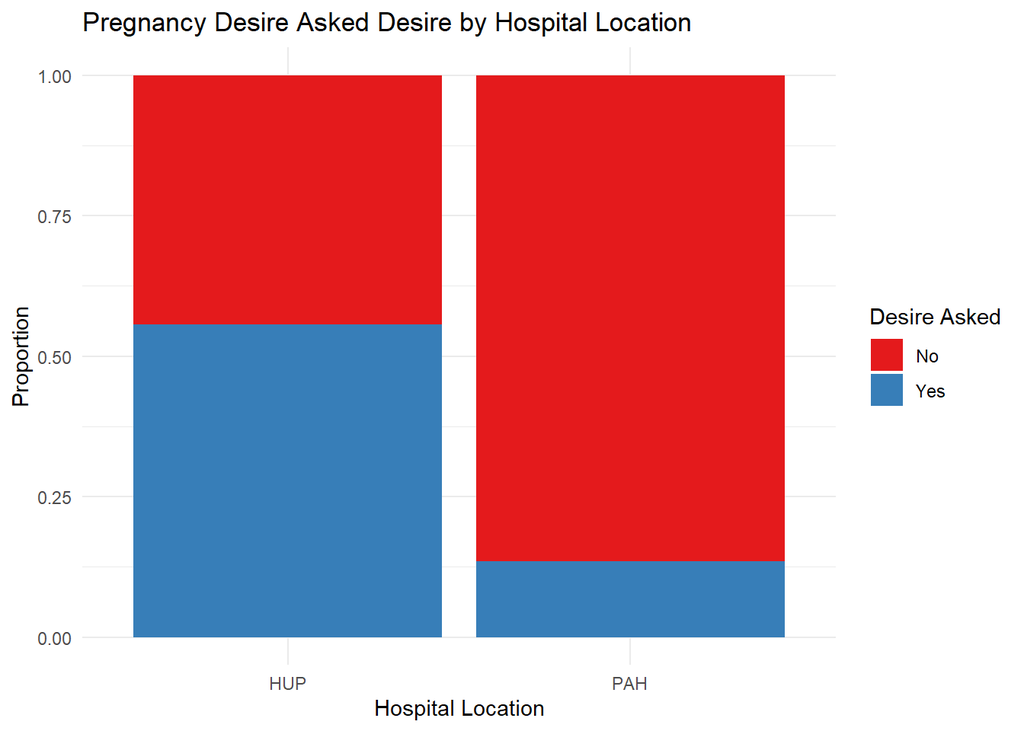

```r
#HOSPITAL.Desire x MG_Responded_Desire

my_colors <- brewer.pal(2, "Set1")


# Create the ggplot with title, informative legend, and color palette
preg_desire |>
filter(HOSPITAL != "") |> #Filter to only include values no NAs
ggplot(
  aes(HOSPITAL, fill = MG_Responded_Desire)) +
  geom_bar(position = "fill") +
  labs(
    x = "Hospital Location",
    y = "Proportion",
    fill = "Responded Desire",
    title = "Pregnancy Desire Asked Desire by Hospital Location"
  ) +
  scale_fill_manual(
    name = "Desire Asked",
    values = my_colors,
    labels = c("No", "Yes"),
    breaks = c("No", "Yes")
  ) +
  theme_minimal()
```

Pregnancy Desire Asked by Gestational Age

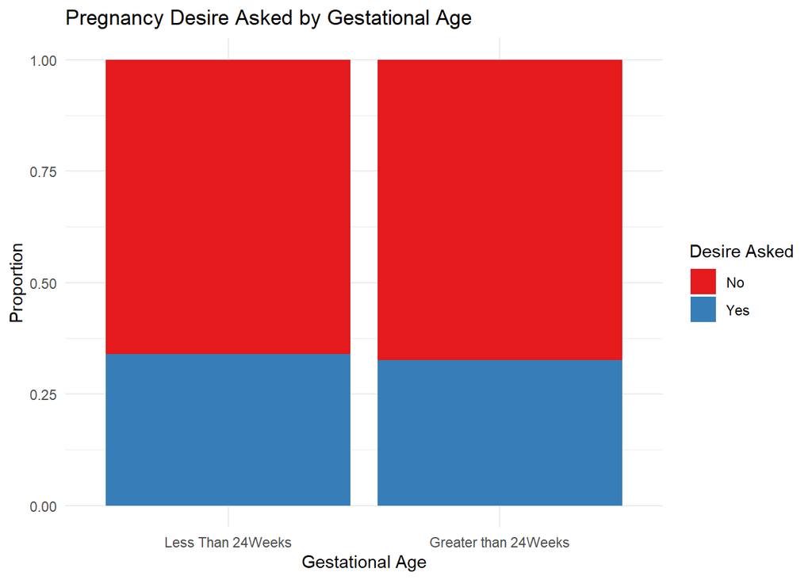

```r
#MG_GA x MG_Responded_Desire

my_colors <- brewer.pal(2, "Set1")


# Create the ggplot with title, informative legend, and color palette
preg_desire |>
filter(MG_GA != "") |> #Filter to only include values no NAs
ggplot(
  aes(MG_GA, fill = MG_Responded_Desire)) +
  geom_bar(position = "fill") +
  labs(
    x = "Gestational Age",
    y = "Proportion",
    fill = "Responded Desire",
    title = "Pregnancy Desire Asked by Gestational Age"
  ) +
  scale_fill_manual(
    name = "Desire Asked",
    values = my_colors,
    labels = c("No", "Yes"),
    breaks = c("No", "Yes")
  ) +
  theme_minimal()
```

Pregnancy Desire Asked by ER Utilization

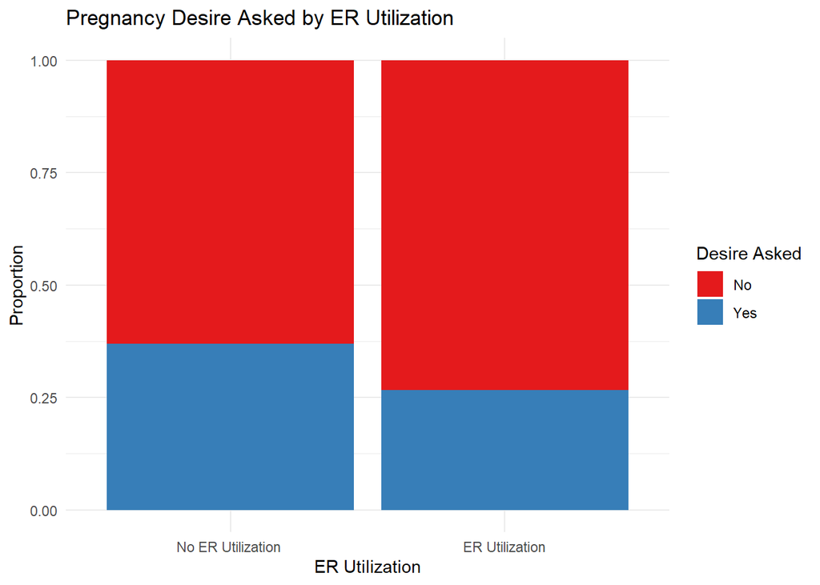

```r
#ER_Utilization.Desire x MG_Responded_Desire

my_colors <- brewer.pal(2, "Set1")


# Create the ggplot with title, informative legend, and color palette
preg_desire |>
filter(MG_ER_Utilization != "") |> #Filter to only include values no NAs
ggplot(
  aes(MG_ER_Utilization, fill = MG_Responded_Desire)) +
  geom_bar(position = "fill") +
  labs(
    x = "ER Utilization",
    y = "Proportion",
    fill = "Responded Desire",
    title = "Pregnancy Desire Asked by ER Utilization"
  ) +
  scale_fill_manual(
    name = "Desire Asked",
    values = my_colors,
    labels = c("No", "Yes"),
    breaks = c("No", "Yes")
  ) +
  theme_minimal()
```

## 12 Stratified analysis

Next, I am going to perform a stratified analysis for potential confounding variables to better understand the relationship between the predictor variables and the outcome variable.

I begin by stratifying for race

```r
#Stratified analysis comparing variables of interest to outcome variable and controlling for confounders

strat.race <- tbl_strata(
  data = preg_desire,
  strata = HOSPITAL,
                            ~ .x |>
                            tbl_summary(by=MF_Race_Cat) |>
    modify_header(label ~ paste0("strat.race" , today(), "Stratifying for Race"))|>
    add_p()

)

strat.race
```

| strat.race2023-12-13Stratifying for Race | **HUP** **White/Other**, N = 1,331<sup>1</sup> | **HUP** **Black**, N = 2,811<sup>1</sup> | **HUP** **p-value**<sup>2</sup> | **PAH** **White/Other**, N = 3,288<sup>1</sup> | **PAH** **Black**, N = 1,507<sup>1</sup> | **PAH** **p-value**<sup>2</sup> |
| --- | --- | --- | --- | --- | --- | --- |
| MG_Responded_Desire | 708 (53%) | 1,611 (57%) | 0.013 | 147 (4.5%) | 479 (32%) | <0.001 |
| MF_Age |  |  | <0.001 |  |  | <0.001 |
| 19 and Under | 3 (0.2%) | 166 (6.7%) |  | 16 (0.5%) | 72 (5.1%) |  |
| 20-24 years | 73 (5.8%) | 569 (23%) |  | 123 (3.9%) | 295 (21%) |  |
| 25-29 years | 236 (19%) | 809 (33%) |  | 477 (15%) | 447 (32%) |  |
| 30-34 years | 539 (43%) | 591 (24%) |  | 1,529 (48%) | 358 (25%) |  |
| 35-39 years | 356 (28%) | 277 (11%) |  | 880 (28%) | 185 (13%) |  |
| 40-44 years | 61 (4.8%) | 74 (3.0%) |  | 154 (4.8%) | 47 (3.3%) |  |
| Unknown | 63 | 325 |  | 109 | 103 |  |
| MF_ethnicity |  |  | <0.001 |  |  | <0.001 |
| Non-Hispanic | 1,277 (97%) | 2,759 (99%) |  | 3,109 (95%) | 1,472 (98%) |  |
| Hispanic | 42 (3.2%) | 36 (1.3%) |  | 152 (4.7%) | 28 (1.9%) |  |
| Unknown | 12 | 16 |  | 27 | 7 |  |
| MF_Insurance_Cat |  |  | <0.001 |  |  | <0.001 |
| Private | 938 (73%) | 633 (25%) |  | 2,483 (77%) | 501 (35%) |  |
| Public/Uninsured | 346 (27%) | 1,941 (75%) |  | 723 (23%) | 937 (65%) |  |
| Unknown | 47 | 237 |  | 82 | 69 |  |
| MF_Entry_Obese |  |  | <0.001 |  |  | <0.001 |
| Not Obese | 953 (80%) | 1,061 (51%) |  | 2,492 (83%) | 627 (51%) |  |
| Obese | 240 (20%) | 1,001 (49%) |  | 512 (17%) | 611 (49%) |  |
| Unknown | 138 | 749 |  | 284 | 269 |  |
| MF_Entry_Encounter_Type |  |  | <0.001 |  |  | <0.001 |
| Hospital Encounter | 53 (4.2%) | 214 (8.6%) |  | 422 (13%) | 125 (8.9%) |  |
| Office Visit | 1,022 (81%) | 1,349 (54%) |  | 2,503 (79%) | 1,031 (73%) |  |
| Procedure | 193 (15%) | 923 (37%) |  | 254 (8.0%) | 248 (18%) |  |
| Unknown | 63 | 325 |  | 109 | 103 |  |
| MG_GA |  |  | 0.002 |  |  | <0.001 |
| Less Than 24Weeks | 3 (0.2%) | 33 (1.2%) |  | 6 (0.2%) | 14 (0.9%) |  |
| Greater than 24Weeks | 1,321 (100%) | 2,765 (99%) |  | 3,276 (100%) | 1,490 (99%) |  |
| Unknown | 7 | 13 |  | 6 | 3 |  |
| MG_ER_Utilization |  |  | <0.001 |  |  | <0.001 |
| No ER Utilization | 1,189 (89%) | 2,017 (72%) |  | 1,455 (44%) | 468 (31%) |  |
| ER Utilization | 142 (11%) | 794 (28%) |  | 1,833 (56%) | 1,039 (69%) |  |

<sup>1</sup> n (%)  
<sup>2</sup> Pearson’s Chi-squared test

```r
#Create a subset data set to only include variables of interest
```

Stratifying for Age

```r
#Stratified analysis comparing variables of interest to outcome variable and controlling for confounders

strat.age <- tbl_strata(
  data = preg_desire,
  strata = MG_Responded_Desire,
                            ~ .x |>
                            tbl_summary(by=MF_Age) |>
    modify_header(label ~ paste0("strat.age" , today(), "Stratifying for Age"))|>
    add_p()

)

strat.age
```

| strat.age2023-12-13Stratifying for Age | **No** **19 and Under**, N = 118<sup>1</sup> | **No** **20-24 years**, N = 534<sup>1</sup> | **No** **25-29 years**, N = 1,281<sup>1</sup> | **No** **30-34 years**, N = 2,328<sup>1</sup> | **No** **35-39 years**, N = 1,367<sup>1</sup> | **No** **40-44 years**, N = 260<sup>1</sup> | **No** **p-value**<sup>2</sup> | **Yes** **19 and Under**, N = 166<sup>1</sup> | **Yes** **20-24 years**, N = 640<sup>1</sup> | **Yes** **25-29 years**, N = 888<sup>1</sup> | **Yes** **30-34 years**, N = 882<sup>1</sup> | **Yes** **35-39 years**, N = 419<sup>1</sup> | **Yes** **40-44 years**, N = 98<sup>1</sup> | **Yes** **p-value**<sup>2</sup> |
| --- | --- | --- | --- | --- | --- | --- | --- | --- | --- | --- | --- | --- | --- | --- |
| MF_Race_Cat |  |  |  |  |  |  | <0.001 |  |  |  |  |  |  | <0.001 |
| White/Other | 12 (12%) | 117 (25%) | 533 (47%) | 1,727 (79%) | 1,036 (80%) | 177 (73%) |  | 7 (4.5%) | 79 (13%) | 180 (22%) | 341 (41%) | 200 (50%) | 38 (40%) |  |
| Black | 91 (88%) | 352 (75%) | 613 (53%) | 464 (21%) | 260 (20%) | 64 (27%) |  | 147 (95%) | 512 (87%) | 643 (78%) | 485 (59%) | 202 (50%) | 57 (60%) |  |
| Unknown | 15 | 65 | 135 | 137 | 71 | 19 |  | 12 | 49 | 65 | 56 | 17 | 3 |  |
| MF_ethnicity |  |  |  |  |  |  | <0.001 |  |  |  |  |  |  | 0.005 |
| Non-Hispanic | 102 (86%) | 446 (84%) | 1,124 (88%) | 2,179 (95%) | 1,291 (95%) | 231 (91%) |  | 150 (91%) | 578 (91%) | 806 (91%) | 829 (95%) | 393 (94%) | 94 (96%) |  |
| Hispanic | 16 (14%) | 85 (16%) | 150 (12%) | 124 (5.4%) | 63 (4.7%) | 24 (9.4%) |  | 15 (9.1%) | 59 (9.3%) | 75 (8.5%) | 44 (5.0%) | 23 (5.5%) | 4 (4.1%) |  |
| Unknown | 0 | 3 | 7 | 25 | 13 | 5 |  | 1 | 3 | 7 | 9 | 3 | 0 |  |
| MF_Insurance_Cat |  |  |  |  |  |  | <0.001 |  |  |  |  |  |  | <0.001 |
| Private | 16 (14%) | 140 (26%) | 610 (48%) | 1,740 (75%) | 1,037 (76%) | 181 (70%) |  | 14 (8.4%) | 130 (20%) | 245 (28%) | 401 (45%) | 211 (50%) | 47 (48%) |  |
| Public/Uninsured | 102 (86%) | 394 (74%) | 671 (52%) | 588 (25%) | 330 (24%) | 79 (30%) |  | 152 (92%) | 510 (80%) | 643 (72%) | 481 (55%) | 208 (50%) | 51 (52%) |  |
| MF_Entry_Obese |  |  |  |  |  |  | <0.001 |  |  |  |  |  |  | 0.009 |
| Not Obese | 52 (76%) | 238 (62%) | 665 (66%) | 1,610 (77%) | 963 (78%) | 169 (74%) |  | 109 (70%) | 397 (63%) | 489 (56%) | 517 (60%) | 247 (60%) | 53 (56%) |  |
| Obese | 16 (24%) | 143 (38%) | 341 (34%) | 477 (23%) | 279 (22%) | 58 (26%) |  | 47 (30%) | 238 (37%) | 389 (44%) | 351 (40%) | 162 (40%) | 42 (44%) |  |
| Unknown | 50 | 153 | 275 | 241 | 125 | 33 |  | 10 | 5 | 10 | 14 | 10 | 3 |  |
| MF_Entry_Encounter_Type |  |  |  |  |  |  | <0.001 |  |  |  |  |  |  | <0.001 |
| Hospital Encounter | 11 (9.3%) | 60 (11%) | 152 (12%) | 287 (12%) | 172 (13%) | 22 (8.5%) |  | 9 (5.4%) | 36 (5.6%) | 48 (5.4%) | 42 (4.8%) | 19 (4.5%) | 6 (6.1%) |  |
| Office Visit | 54 (46%) | 297 (56%) | 813 (63%) | 1,722 (74%) | 1,042 (76%) | 186 (72%) |  | 105 (63%) | 438 (68%) | 614 (69%) | 686 (78%) | 336 (80%) | 73 (74%) |  |
| Procedure | 53 (45%) | 177 (33%) | 316 (25%) | 319 (14%) | 153 (11%) | 52 (20%) |  | 52 (31%) | 166 (26%) | 226 (25%) | 154 (17%) | 64 (15%) | 19 (19%) |  |
| HOSPITAL |  |  |  |  |  |  | <0.001 |  |  |  |  |  |  | <0.001 |
| HUP | 56 (47%) | 221 (41%) | 447 (35%) | 484 (21%) | 313 (23%) | 56 (22%) |  | 124 (75%) | 454 (71%) | 664 (75%) | 715 (81%) | 349 (83%) | 83 (85%) |  |
| PAH | 62 (53%) | 313 (59%) | 834 (65%) | 1,844 (79%) | 1,054 (77%) | 204 (78%) |  | 42 (25%) | 186 (29%) | 224 (25%) | 167 (19%) | 70 (17%) | 15 (15%) |  |
| MG_GA |  |  |  |  |  |  | 0.5 |  |  |  |  |  |  | 0.015 |
| Less Than 24Weeks | 1 (0.8%) | 2 (0.4%) | 7 (0.5%) | 8 (0.3%) | 3 (0.2%) | 1 (0.4%) |  | 0 (0%) | 1 (0.2%) | 14 (1.6%) | 4 (0.5%) | 1 (0.2%) | 0 (0%) |  |
| Greater than 24Weeks | 117 (99%) | 529 (100%) | 1,272 (99%) | 2,312 (100%) | 1,364 (100%) | 258 (100%) |  | 166 (100%) | 639 (100%) | 874 (98%) | 877 (100%) | 418 (100%) | 98 (100%) |  |
| Unknown | 0 | 3 | 2 | 8 | 0 | 1 |  | 0 | 0 | 0 | 1 | 0 | 0 |  |
| MG_ER_Utilization |  |  |  |  |  |  | 0.089 |  |  |  |  |  |  | <0.001 |
| No ER Utilization | 65 (55%) | 264 (49%) | 638 (50%) | 1,241 (53%) | 748 (55%) | 140 (54%) |  | 91 (55%) | 358 (56%) | 548 (62%) | 635 (72%) | 312 (74%) | 71 (72%) |  |
| ER Utilization | 53 (45%) | 270 (51%) | 643 (50%) | 1,087 (47%) | 619 (45%) | 120 (46%) |  | 75 (45%) | 282 (44%) | 340 (38%) | 247 (28%) | 107 (26%) | 27 (28%) |  |

<sup>1</sup> n (%)  
<sup>2</sup> Pearson’s Chi-squared test; Fisher’s exact test

```r
#Create a subset data set to only include variables of interest
```

Stratifying for Gestational Age

```r
#Stratified analysis comparing variables of interest to outcome variable and controlling for confounders

strat.GA <- tbl_strata(
  data = preg_desire,
  strata = MG_Responded_Desire,
                            ~ .x |>
                            tbl_summary(by=MG_GA) |>
    modify_header(label ~ paste0("strat.GA" , today(), "Stratifying for Gestational Age"))|>
    add_p()

)

strat.GA
```

| strat.GA2023-12-13Stratifying for Gestational Age | **No** **Less Than 24Weeks**, N = 39<sup>1</sup> | **No** **Greater than 24Weeks**, N = 6,454<sup>1</sup> | **No** **p-value**<sup>2</sup> | **Yes** **Less Than 24Weeks**, N = 20<sup>1</sup> | **Yes** **Greater than 24Weeks**, N = 3,128<sup>1</sup> | **Yes** **p-value**<sup>2</sup> |
| --- | --- | --- | --- | --- | --- | --- |
| MF_Race_Cat |  |  | <0.001 |  |  | 0.018 |
| White/Other | 8 (22%) | 3,744 (63%) |  | 1 (5.0%) | 853 (29%) |  |
| Black | 28 (78%) | 2,184 (37%) |  | 19 (95%) | 2,071 (71%) |  |
| Unknown | 3 | 526 |  | 0 | 204 |  |
| MF_Age |  |  | 0.5 |  |  | 0.015 |
| 19 and Under | 1 (4.5%) | 117 (2.0%) |  | 0 (0%) | 166 (5.4%) |  |
| 20-24 years | 2 (9.1%) | 529 (9.0%) |  | 1 (5.0%) | 639 (21%) |  |
| 25-29 years | 7 (32%) | 1,272 (22%) |  | 14 (70%) | 874 (28%) |  |
| 30-34 years | 8 (36%) | 2,312 (40%) |  | 4 (20%) | 877 (29%) |  |
| 35-39 years | 3 (14%) | 1,364 (23%) |  | 1 (5.0%) | 418 (14%) |  |
| 40-44 years | 1 (4.5%) | 258 (4.4%) |  | 0 (0%) | 98 (3.2%) |  |
| Unknown | 17 | 602 |  | 0 | 56 |  |
| MF_ethnicity |  |  | >0.9 |  |  | 0.4 |
| Non-Hispanic | 34 (92%) | 5,852 (91%) |  | 20 (100%) | 2,882 (93%) |  |
| Hispanic | 3 (8.1%) | 544 (8.5%) |  | 0 (0%) | 222 (7.2%) |  |
| Unknown | 2 | 58 |  | 0 | 24 |  |
| MF_Insurance_Cat |  |  | <0.001 |  |  | 0.4 |
| Private | 9 (31%) | 3,723 (62%) |  | 5 (25%) | 1,043 (34%) |  |
| Public/Uninsured | 20 (69%) | 2,302 (38%) |  | 15 (75%) | 2,030 (66%) |  |
| Unknown | 10 | 429 |  | 0 | 55 |  |
| MF_Entry_Obese |  |  | 0.043 |  |  | 0.12 |
| Not Obese | 8 (50%) | 3,683 (74%) |  | 8 (42%) | 1,804 (60%) |  |
| Obese | 8 (50%) | 1,305 (26%) |  | 11 (58%) | 1,217 (40%) |  |
| Unknown | 23 | 1,466 |  | 1 | 107 |  |
| MF_Entry_Encounter_Type |  |  | 0.2 |  |  | 0.3 |
| Hospital Encounter | 3 (14%) | 697 (12%) |  | 1 (5.0%) | 159 (5.2%) |  |
| Office Visit | 12 (55%) | 4,097 (70%) |  | 12 (60%) | 2,240 (73%) |  |
| Procedure | 7 (32%) | 1,058 (18%) |  | 7 (35%) | 673 (22%) |  |
| Unknown | 17 | 602 |  | 0 | 56 |  |
| HOSPITAL |  |  | <0.001 |  |  | >0.9 |
| HUP | 21 (54%) | 1,909 (30%) |  | 16 (80%) | 2,421 (77%) |  |
| PAH | 18 (46%) | 4,545 (70%) |  | 4 (20%) | 707 (23%) |  |
| MG_ER_Utilization |  |  | 0.049 |  |  | 0.018 |
| No ER Utilization | 27 (69%) | 3,451 (53%) |  | 8 (40%) | 2,043 (65%) |  |
| ER Utilization | 12 (31%) | 3,003 (47%) |  | 12 (60%) | 1,085 (35%) |  |

<sup>1</sup> n (%)  
<sup>2</sup> Pearson’s Chi-squared test; Fisher’s exact test

```r
#Create a subset data set to only include variables of interest
```

Stratifying for Hospital Location

```r
#Stratified analysis comparing variables of interest to outcome variable and controlling for confounders

strat.hospital <- tbl_strata(
  data = preg_desire,
  strata = MG_Responded_Desire,
                            ~ .x |>
                            tbl_summary(by=HOSPITAL) |>
    modify_header(label ~ paste0("strat.hospital" , today(), "Stratifying for Hospital Location")) |>
    add_p()

)

strat.hospital
```

| strat.hospital2023-12-13Stratifying for Hospital Location | **No** **HUP**, N = 1,949<sup>1</sup> | **No** **PAH**, N = 4,574<sup>1</sup> | **No** **p-value**<sup>2</sup> | **Yes** **HUP**, N = 2,438<sup>1</sup> | **Yes** **PAH**, N = 711<sup>1</sup> | **Yes** **p-value**<sup>3</sup> |
| --- | --- | --- | --- | --- | --- | --- |
| MF_Race_Cat |  |  | <0.001 |  |  | <0.001 |
| White/Other | 623 (34%) | 3,141 (75%) |  | 708 (31%) | 147 (23%) |  |
| Black | 1,200 (66%) | 1,028 (25%) |  | 1,611 (69%) | 479 (77%) |  |
| Unknown | 126 | 405 |  | 119 | 85 |  |
| MF_Age |  |  | <0.001 |  |  | <0.001 |
| 19 and Under | 56 (3.6%) | 62 (1.4%) |  | 124 (5.2%) | 42 (6.0%) |  |
| 20-24 years | 221 (14%) | 313 (7.3%) |  | 454 (19%) | 186 (26%) |  |
| 25-29 years | 447 (28%) | 834 (19%) |  | 664 (28%) | 224 (32%) |  |
| 30-34 years | 484 (31%) | 1,844 (43%) |  | 715 (30%) | 167 (24%) |  |
| 35-39 years | 313 (20%) | 1,054 (24%) |  | 349 (15%) | 70 (9.9%) |  |
| 40-44 years | 56 (3.6%) | 204 (4.7%) |  | 83 (3.5%) | 15 (2.1%) |  |
| Unknown | 372 | 263 |  | 49 | 7 |  |
| MF_ethnicity |  |  | <0.001 |  |  | <0.001 |
| Non-Hispanic | 1,844 (95%) | 4,070 (90%) |  | 2,296 (95%) | 607 (86%) |  |
| Hispanic | 89 (4.6%) | 460 (10%) |  | 123 (5.1%) | 99 (14%) |  |
| Unknown | 16 | 44 |  | 19 | 5 |  |
| MF_Insurance_Cat |  |  | <0.001 |  |  | <0.001 |
| Private | 740 (44%) | 2,998 (68%) |  | 911 (38%) | 137 (19%) |  |
| Public/Uninsured | 948 (56%) | 1,385 (32%) |  | 1,479 (62%) | 567 (81%) |  |
| Unknown | 261 | 191 |  | 48 | 7 |  |
| MF_Entry_Obese |  |  | <0.001 |  |  | 0.060 |
| Not Obese | 716 (65%) | 2,981 (76%) |  | 1,414 (61%) | 398 (57%) |  |
| Obese | 378 (35%) | 936 (24%) |  | 923 (39%) | 306 (43%) |  |
| Unknown | 855 | 657 |  | 101 | 7 |  |
| MF_Entry_Encounter_Type |  |  | <0.001 |  |  | <0.001 |
| Hospital Encounter | 175 (11%) | 529 (12%) |  | 107 (4.5%) | 53 (7.5%) |  |
| Office Visit | 840 (53%) | 3,274 (76%) |  | 1,665 (70%) | 587 (83%) |  |
| Procedure | 562 (36%) | 508 (12%) |  | 617 (26%) | 64 (9.1%) |  |
| Unknown | 372 | 263 |  | 49 | 7 |  |
| MG_GA |  |  | <0.001 |  |  | >0.9 |
| Less Than 24Weeks | 21 (1.1%) | 18 (0.4%) |  | 16 (0.7%) | 4 (0.6%) |  |
| Greater than 24Weeks | 1,909 (99%) | 4,545 (100%) |  | 2,421 (99%) | 707 (99%) |  |
| Unknown | 19 | 11 |  | 1 | 0 |  |
| MG_ER_Utilization |  |  | <0.001 |  |  | <0.001 |
| No ER Utilization | 1,589 (82%) | 1,909 (42%) |  | 1,832 (75%) | 220 (31%) |  |
| ER Utilization | 360 (18%) | 2,665 (58%) |  | 606 (25%) | 491 (69%) |  |

<sup>1</sup> n (%)  
<sup>2</sup> Pearson’s Chi-squared test  
<sup>3</sup> Pearson’s Chi-squared test; Fisher’s exact test

```r
#Create a subset data set to only include variables of interest
```

Stratifying for Type of Insurance

Similarly to the hospital stratification above, we see that there are noteworthy disparities between a patients’ insurance status in relation to patient characteristics.

```r
#Stratified analysis comparing variables of interest to outcome variable and controlling for confounders

strat.insurance <- tbl_strata(
  data = preg_desire,
  strata = MG_Responded_Desire,
                            ~ .x |>
                            tbl_summary(by=MF_Insurance_Cat) |>
    modify_header(label ~ paste0("strat.insurance" , today(), "Stratifying for Type of Insurance"))|>
    add_p()

)

strat.insurance
```

| strat.insurance2023-12-13Stratifying for Type of Insurance | **No** **Private**, N = 3,738<sup>1</sup> | **No** **Public/Uninsured**, N = 2,333<sup>1</sup> | **No** **p-value**<sup>2</sup> | **Yes** **Private**, N = 1,048<sup>1</sup> | **Yes** **Public/Uninsured**, N = 2,046<sup>1</sup> | **Yes** **p-value**<sup>2</sup> |
| --- | --- | --- | --- | --- | --- | --- |
| MF_Race_Cat |  |  | <0.001 |  |  | <0.001 |
| White/Other | 2,878 (81%) | 767 (37%) |  | 543 (54%) | 302 (16%) |  |
| Black | 677 (19%) | 1,288 (63%) |  | 457 (46%) | 1,590 (84%) |  |
| Unknown | 183 | 278 |  | 48 | 154 |  |
| MF_Age |  |  | <0.001 |  |  | <0.001 |
| 19 and Under | 16 (0.4%) | 102 (4.7%) |  | 14 (1.3%) | 152 (7.4%) |  |
| 20-24 years | 140 (3.8%) | 394 (18%) |  | 130 (12%) | 510 (25%) |  |
| 25-29 years | 610 (16%) | 671 (31%) |  | 245 (23%) | 643 (31%) |  |
| 30-34 years | 1,740 (47%) | 588 (27%) |  | 401 (38%) | 481 (24%) |  |
| 35-39 years | 1,037 (28%) | 330 (15%) |  | 211 (20%) | 208 (10%) |  |
| 40-44 years | 181 (4.9%) | 79 (3.7%) |  | 47 (4.5%) | 51 (2.5%) |  |
| Unknown | 14 | 169 |  | 0 | 1 |  |
| MF_ethnicity |  |  | <0.001 |  |  | <0.001 |
| Non-Hispanic | 3,541 (96%) | 1,989 (86%) |  | 988 (95%) | 1,863 (92%) |  |
| Hispanic | 159 (4.3%) | 325 (14%) |  | 52 (5.0%) | 168 (8.3%) |  |
| Unknown | 38 | 19 |  | 8 | 15 |  |
| MF_Entry_Obese |  |  | <0.001 |  |  | <0.001 |
| Not Obese | 2,751 (79%) | 946 (63%) |  | 705 (68%) | 1,107 (55%) |  |
| Obese | 752 (21%) | 562 (37%) |  | 331 (32%) | 898 (45%) |  |
| Unknown | 235 | 825 |  | 12 | 41 |  |
| MF_Entry_Encounter_Type |  |  | <0.001 |  |  | <0.001 |
| Hospital Encounter | 430 (12%) | 274 (13%) |  | 37 (3.5%) | 123 (6.0%) |  |
| Office Visit | 2,960 (79%) | 1,154 (53%) |  | 886 (85%) | 1,366 (67%) |  |
| Procedure | 334 (9.0%) | 736 (34%) |  | 125 (12%) | 556 (27%) |  |
| Unknown | 14 | 169 |  | 0 | 1 |  |
| HOSPITAL |  |  | <0.001 |  |  | <0.001 |
| HUP | 740 (20%) | 948 (41%) |  | 911 (87%) | 1,479 (72%) |  |
| PAH | 2,998 (80%) | 1,385 (59%) |  | 137 (13%) | 567 (28%) |  |
| MG_GA |  |  | <0.001 |  |  | 0.4 |
| Less Than 24Weeks | 9 (0.2%) | 20 (0.9%) |  | 5 (0.5%) | 15 (0.7%) |  |
| Greater than 24Weeks | 3,723 (100%) | 2,302 (99%) |  | 1,043 (100%) | 2,030 (99%) |  |
| Unknown | 6 | 11 |  | 0 | 1 |  |
| MG_ER_Utilization |  |  | 0.3 |  |  | <0.001 |
| No ER Utilization | 1,995 (53%) | 1,215 (52%) |  | 842 (80%) | 1,174 (57%) |  |
| ER Utilization | 1,743 (47%) | 1,118 (48%) |  | 206 (20%) | 872 (43%) |  |

<sup>1</sup> n (%)  
<sup>2</sup> Pearson’s Chi-squared test

```r
#Create a subset data set to only include variables of interest
```

Stratifying for ER Utilization

```r
#Stratified analysis comparing variables of interest to outcome variable and controlling for confounders

strat.ER <- tbl_strata(
  data = preg_desire,
  strata = MG_Responded_Desire,
                            ~ .x |>
                            tbl_summary(by=MG_ER_Utilization) |>
    modify_header(label ~ paste0("strat.ER" , today(), "Stratifying for ER Utilization"))|>
    add_p()

)

strat.ER
```

| strat.ER2023-12-13Stratifying for ER Utilization | **No** **No ER Utilization **, N = 3,498<sup>1</sup> | **No** **ER Utilization**, N = 3,025<sup>1</sup> | **No** **p-value**<sup>2</sup> | **Yes** **No ER Utilization **, N = 2,052<sup>1</sup> | **Yes** **ER Utilization**, N = 1,097<sup>1</sup> | **Yes** **p-value**<sup>2</sup> |
| --- | --- | --- | --- | --- | --- | --- |
| MF_Race_Cat |  |  | 0.041 |  |  | <0.001 |
| White/Other | 1,977 (62%) | 1,787 (64%) |  | 667 (35%) | 188 (18%) |  |
| Black | 1,231 (38%) | 997 (36%) |  | 1,254 (65%) | 836 (82%) |  |
| Unknown | 290 | 241 |  | 131 | 73 |  |
| MF_Age |  |  | 0.089 |  |  | <0.001 |
| 19 and Under | 65 (2.1%) | 53 (1.9%) |  | 91 (4.5%) | 75 (7.0%) |  |
| 20-24 years | 264 (8.5%) | 270 (9.7%) |  | 358 (18%) | 282 (26%) |  |
| 25-29 years | 638 (21%) | 643 (23%) |  | 548 (27%) | 340 (32%) |  |
| 30-34 years | 1,241 (40%) | 1,087 (39%) |  | 635 (32%) | 247 (23%) |  |
| 35-39 years | 748 (24%) | 619 (22%) |  | 312 (15%) | 107 (9.9%) |  |
| 40-44 years | 140 (4.5%) | 120 (4.3%) |  | 71 (3.5%) | 27 (2.5%) |  |
| Unknown | 402 | 233 |  | 37 | 19 |  |
| MF_ethnicity |  |  | 0.003 |  |  | 0.002 |
| Non-Hispanic | 3,205 (92%) | 2,709 (90%) |  | 1,910 (94%) | 993 (91%) |  |
| Hispanic | 261 (7.5%) | 288 (9.6%) |  | 123 (6.1%) | 99 (9.1%) |  |
| Unknown | 32 | 28 |  | 19 | 5 |  |
| MF_Insurance_Cat |  |  | 0.3 |  |  | <0.001 |
| Private | 1,995 (62%) | 1,743 (61%) |  | 842 (42%) | 206 (19%) |  |
| Public/Uninsured | 1,215 (38%) | 1,118 (39%) |  | 1,174 (58%) | 872 (81%) |  |
| Unknown | 288 | 164 |  | 36 | 19 |  |
| MF_Entry_Obese |  |  | <0.001 |  |  | <0.001 |
| Not Obese | 1,969 (76%) | 1,728 (71%) |  | 1,216 (62%) | 596 (55%) |  |
| Obese | 610 (24%) | 704 (29%) |  | 750 (38%) | 479 (45%) |  |
| Unknown | 919 | 593 |  | 86 | 22 |  |
| MF_Entry_Encounter_Type |  |  | 0.12 |  |  | <0.001 |
| Hospital Encounter | 362 (12%) | 342 (12%) |  | 76 (3.8%) | 84 (7.8%) |  |
| Office Visit | 2,141 (69%) | 1,973 (71%) |  | 1,489 (74%) | 763 (71%) |  |
| Procedure | 593 (19%) | 477 (17%) |  | 450 (22%) | 231 (21%) |  |
| Unknown | 402 | 233 |  | 37 | 19 |  |
| HOSPITAL |  |  | <0.001 |  |  | <0.001 |
| HUP | 1,589 (45%) | 360 (12%) |  | 1,832 (89%) | 606 (55%) |  |
| PAH | 1,909 (55%) | 2,665 (88%) |  | 220 (11%) | 491 (45%) |  |
| MG_GA |  |  | 0.049 |  |  | 0.018 |
| Less Than 24Weeks | 27 (0.8%) | 12 (0.4%) |  | 8 (0.4%) | 12 (1.1%) |  |
| Greater than 24Weeks | 3,451 (99%) | 3,003 (100%) |  | 2,043 (100%) | 1,085 (99%) |  |
| Unknown | 20 | 10 |  | 1 | 0 |  |

<sup>1</sup> n (%)  
<sup>2</sup> Pearson’s Chi-squared test

```r
#Create a subset data set to only include variables of interest
```

## 13 Logistic Regression

Next, I am going to run a logistic regression model for insight into the likelihood that an individual is asked the “Pregnancy Desire” question. The AUC of the logistic regresssion is 0.86 indicating that the model performs well at predicting the likelihood that an individual will be asked the pregnancy desire question.

```r
##Check for normal distribution of data and types of methods to use
#Logistic Regression and ROC

preg_desire.glm <- glm(MG_Responded_Desire ~ MF_Age+MF_Race_Cat+MF_ethnicity+MF_Entry_Obese+MF_Insurance_Cat+HOSPITAL+MG_GA+MF_Entry_Encounter_Type+MG_ER_Utilization , data = preg_desire, family = binomial(logit))
summary(preg_desire.glm)
```

```
Call:
glm(formula = MG_Responded_Desire ~ MF_Age + MF_Race_Cat + MF_ethnicity +
    MF_Entry_Obese + MF_Insurance_Cat + HOSPITAL + MG_GA + MF_Entry_Encounter_Type +
    MG_ER_Utilization, family = binomial(logit), data = preg_desire)

Coefficients:
                                    Estimate Std. Error z value Pr(>|z|)
(Intercept)                          0.18809    0.51313   0.367 0.713957
MF_Age20-24 years                   -0.13276    0.20300  -0.654 0.513110
MF_Age25-29 years                   -0.57631    0.19613  -2.938 0.003299 **
MF_Age30-34 years                   -0.68961    0.19737  -3.494 0.000476 ***
MF_Age35-39 years                   -0.89317    0.20383  -4.382 1.18e-05 ***
MF_Age40-44 years                   -0.78986    0.24499  -3.224 0.001264 **
MF_Race_CatBlack                     0.85587    0.07410  11.550  < 2e-16 ***
MF_ethnicityHispanic                 0.08497    0.17767   0.478 0.632461
MF_Entry_ObeseObese                  0.06728    0.06877   0.978 0.327912
MF_Insurance_CatPublic/Uninsured     1.05277    0.07042  14.951  < 2e-16 ***
HOSPITALPAH                         -2.38893    0.07275 -32.836  < 2e-16 ***
MG_GAGreater than 24Weeks           -0.38372    0.45286  -0.847 0.396812
MF_Entry_Encounter_TypeOffice Visit  0.61337    0.12663   4.844 1.27e-06 ***
MF_Entry_Encounter_TypeProcedure     0.39523    0.14809   2.669 0.007610 **
MG_ER_UtilizationER Utilization      0.07208    0.07275   0.991 0.321758
---
Signif. codes:  0 '***' 0.001 '**' 0.01 '*' 0.05 '.' 0.1 ' ' 1

(Dispersion parameter for binomial family taken to be 1)

    Null deviance: 9877.2  on 7437  degrees of freedom
Residual deviance: 6559.0  on 7423  degrees of freedom
  (2234 observations deleted due to missingness)
AIC: 6589

Number of Fisher Scoring iterations: 5
```

```r
#Odds ratio
exp(cbind(OR = coef(preg_desire.glm), confint(preg_desire.glm)))
```

```
                                            OR      2.5 %    97.5 %
(Intercept)                         1.20693768 0.44630206 3.3489814
MF_Age20-24 years                   0.87567331 0.58568418 1.2987456
MF_Age25-29 years                   0.56196633 0.38077244 0.8219338
MF_Age30-34 years                   0.50177201 0.33922962 0.7358344
MF_Age35-39 years                   0.40935484 0.27331355 0.6080242
MF_Age40-44 years                   0.45390794 0.27968030 0.7310297
MF_Race_CatBlack                    2.35342094 2.03546629 2.7216831
MF_ethnicityHispanic                1.08868929 0.76528575 1.5365437
MF_Entry_ObeseObese                 1.06959187 0.93450561 1.2236836
MF_Insurance_CatPublic/Uninsured    2.86558438 2.49685870 3.2907311
HOSPITALPAH                         0.09172736 0.07944608 0.1056700
MG_GAGreater than 24Weeks           0.68132030 0.27510552 1.6330773
MF_Entry_Encounter_TypeOffice Visit 1.84663574 1.44429871 2.3729769
MF_Entry_Encounter_TypeProcedure    1.48472182 1.11198222 1.9873220
MG_ER_UtilizationER Utilization     1.07474211 0.93235242 1.2400965
```

```r
glm.pred <- predict(preg_desire.glm, preg_desire, type = "response")
head(glm.pred)
```

```
         1          2          3          4          5          6
0.29142792         NA 0.07969625         NA 0.16474756 0.14606060
```

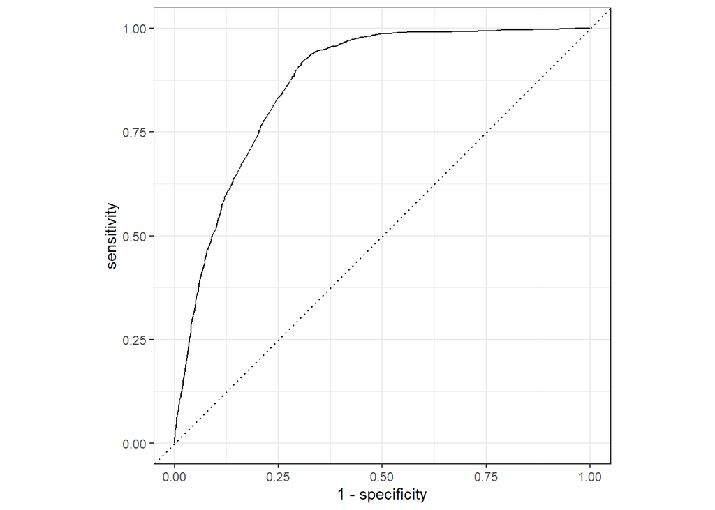

```r
preg_desire.pred.values <- bind_cols(truth = preg_desire$MG_Responded_Desire,
                                 glmpred = glm.pred) |>
  mutate(predicted = factor(case_when(glmpred > 0.5 ~ "Desire Asked",
                               glmpred <= 0.5 ~ "Desire Not Asked")))

autoplot(roc_curve(preg_desire.pred.values,
                   truth, glmpred,
                   event_level = "second"))
```

```r
#Plotting AUC
preg_desire.pred.values |>
    roc_auc(truth, glmpred, event_level = "second")
```

```
# A tibble: 1 × 3
  .metric .estimator .estimate
  <chr>   <chr>          <dbl>
1 roc_auc binary         0.868
```

## 14 Parsnip Approach

Using the parsnip approach which ultimately will yield a forest plot displaying the effect size and confidence intervals.

```r
#parsnip approach
logreg_cls_spec <-
  logistic_reg() |> #specifying logistic regression model (Model Specification)
  set_engine("glm")

#FIGURE OUT HOW TO CREATE THE ODDS RATIO BEFORE CREATING THE PLOT BELOW
# exp(cbind(OR = coef(preg_desire.glm), confint(preg_desire.glm)))

logreg_cls_fit <- logreg_cls_spec |>
  fit(MG_Responded_Desire ~ ., data = preg_desire) # Model Fitting
logreg_cls_fit
```

```
parsnip model object


Call:  stats::glm(formula = MG_Responded_Desire ~ ., family = stats::binomial,
    data = data)

Coefficients:
                        (Intercept)                     MF_Race_CatBlack
                            0.18809                              0.85587
                  MF_Age20-24 years                    MF_Age25-29 years
                           -0.13276                             -0.57631
                  MF_Age30-34 years                    MF_Age35-39 years
                           -0.68961                             -0.89317
                  MF_Age40-44 years                 MF_ethnicityHispanic
                           -0.78986                              0.08497
   MF_Insurance_CatPublic/Uninsured                  MF_Entry_ObeseObese
                            1.05277                              0.06728
MF_Entry_Encounter_TypeOffice Visit     MF_Entry_Encounter_TypeProcedure
                            0.61337                              0.39523
                        HOSPITALPAH            MG_GAGreater than 24Weeks
                           -2.38893                             -0.38372
    MG_ER_UtilizationER Utilization
                            0.07208

Degrees of Freedom: 7437 Total (i.e. Null);  7423 Residual
  (2234 observations deleted due to missingness)
Null Deviance:      9877
Residual Deviance: 6559     AIC: 6589
```

```r
tidy(logreg_cls_fit) #providing an organized summary of the models coef.
```

```
# A tibble: 15 × 5
   term                                estimate std.error statistic   p.value
   <chr>                                  <dbl>     <dbl>     <dbl>     <dbl>
 1 (Intercept)                           0.188     0.513      0.367 7.14e-  1
 2 MF_Race_CatBlack                      0.856     0.0741    11.5   7.42e- 31
 3 MF_Age20-24 years                    -0.133     0.203     -0.654 5.13e-  1
 4 MF_Age25-29 years                    -0.576     0.196     -2.94  3.30e-  3
 5 MF_Age30-34 years                    -0.690     0.197     -3.49  4.76e-  4
 6 MF_Age35-39 years                    -0.893     0.204     -4.38  1.18e-  5
 7 MF_Age40-44 years                    -0.790     0.245     -3.22  1.26e-  3
 8 MF_ethnicityHispanic                  0.0850    0.178      0.478 6.32e-  1
 9 MF_Insurance_CatPublic/Uninsured      1.05      0.0704    15.0   1.54e- 50
10 MF_Entry_ObeseObese                   0.0673    0.0688     0.978 3.28e-  1
11 MF_Entry_Encounter_TypeOffice Visit   0.613     0.127      4.84  1.27e-  6
12 MF_Entry_Encounter_TypeProcedure      0.395     0.148      2.67  7.61e-  3
13 HOSPITALPAH                          -2.39      0.0728   -32.8   1.78e-236
14 MG_GAGreater than 24Weeks            -0.384     0.453     -0.847 3.97e-  1
15 MG_ER_UtilizationER Utilization       0.0721    0.0727     0.991 3.22e-  1
```

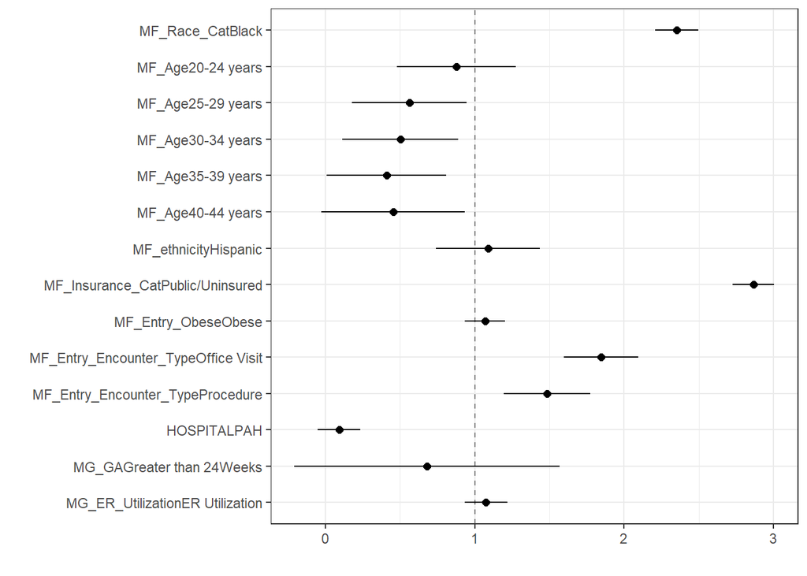

```r
tidy(logreg_cls_fit, exponentiate = TRUE) |>
  dwplot(dot_args = list(size = 2, color = "black"),
         whisker_args = list(color = "black"),
         vline = geom_vline(xintercept = 1, colour = "grey50", linetype = 2)) +
  theme_bw()
```

```r
#Create data frame by binding columns
preg_desire.pred.values <-  bind_cols(
  truth = preg_desire$MG_Responded_Desire, #Observed values of outcome var.
  predict(logreg_cls_fit, preg_desire), #predicted values of log. reg
  predict(logreg_cls_fit, preg_desire, type = "prob") #predicted probabilities of log reg
)
preg_desire.pred.values
```

```
# A tibble: 9,672 × 4
   truth .pred_class .pred_No .pred_Yes
   <fct> <fct>          <dbl>     <dbl>
 1 No    No             0.709    0.291
 2 No    <NA>          NA       NA
 3 No    No             0.920    0.0797
 4 No    <NA>          NA       NA
 5 No    No             0.835    0.165
 6 No    No             0.854    0.146
 7 No    No             0.935    0.0653
 8 No    No             0.863    0.137
 9 No    Yes            0.366    0.634
10 No    No             0.941    0.0595
# ℹ 9,662 more rows
```

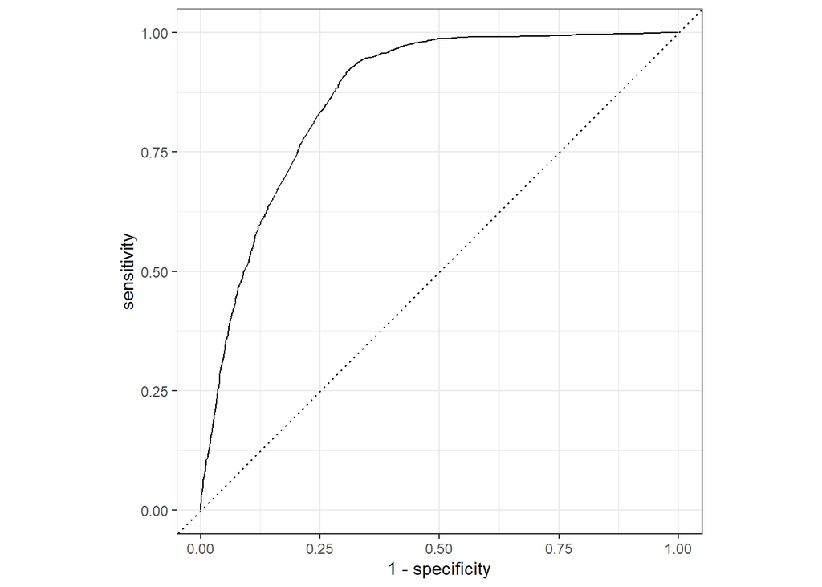

```r
autoplot(roc_curve(preg_desire.pred.values, #Generate ROC plot
                   truth, .pred_Yes, event_level = "second"))
```

```r
roc_auc(preg_desire.pred.values,
                   truth, .pred_Yes, event_level = "second") #Calculate AUC
```

```
# A tibble: 1 × 3
  .metric .estimator .estimate
  <chr>   <chr>          <dbl>
1 roc_auc binary         0.868
```

## 15 Recipes & Cross Validation

Next I will run cross validation to evaluate how my models above perform in comparison.

```r
set.seed(1234)
preg_desire.training.folds <- vfold_cv(preg_desire, v = 10) #creates 10-fold Cross Validation of entire data set (internal validation) ONLY KEEP THIS
preg_desire.training.folds
```

```
#  10-fold cross-validation
# A tibble: 10 × 2
   splits             id
   <list>             <chr>
 1 <split [8704/968]> Fold01
 2 <split [8704/968]> Fold02
 3 <split [8705/967]> Fold03
 4 <split [8705/967]> Fold04
 5 <split [8705/967]> Fold05
 6 <split [8705/967]> Fold06
 7 <split [8705/967]> Fold07
 8 <split [8705/967]> Fold08
 9 <split [8705/967]> Fold09
10 <split [8705/967]> Fold10
```

```r
logreg_workflow <-
  workflow() |>
  add_model(logreg_cls_spec) |>
  add_formula(MG_Responded_Desire ~ .)

set.seed(1234)
logreg_fit_cv <-
  logreg_workflow |>
  fit_resamples(preg_desire.training.folds,
                control = control_resamples(save_pred = TRUE))
logreg_fit_cv
```

```
# Resampling results
# 10-fold cross-validation
# A tibble: 10 × 5
   splits             id     .metrics         .notes           .predictions
   <list>             <chr>  <list>           <list>           <list>
 1 <split [8704/968]> Fold01 <tibble [2 × 4]> <tibble [0 × 3]> <tibble>
 2 <split [8704/968]> Fold02 <tibble [2 × 4]> <tibble [0 × 3]> <tibble>
 3 <split [8705/967]> Fold03 <tibble [2 × 4]> <tibble [0 × 3]> <tibble>
 4 <split [8705/967]> Fold04 <tibble [2 × 4]> <tibble [0 × 3]> <tibble>
 5 <split [8705/967]> Fold05 <tibble [2 × 4]> <tibble [0 × 3]> <tibble>
 6 <split [8705/967]> Fold06 <tibble [2 × 4]> <tibble [0 × 3]> <tibble>
 7 <split [8705/967]> Fold07 <tibble [2 × 4]> <tibble [0 × 3]> <tibble>
 8 <split [8705/967]> Fold08 <tibble [2 × 4]> <tibble [0 × 3]> <tibble>
 9 <split [8705/967]> Fold09 <tibble [2 × 4]> <tibble [0 × 3]> <tibble>
10 <split [8705/967]> Fold10 <tibble [2 × 4]> <tibble [0 × 3]> <tibble>
```

```r
collect_metrics(logreg_fit_cv)
```

```
# A tibble: 2 × 6
  .metric  .estimator  mean     n std_err .config
  <chr>    <chr>      <dbl> <int>   <dbl> <chr>
1 accuracy binary     0.771    10 0.00742 Preprocessor1_Model1
2 roc_auc  binary     0.867    10 0.00603 Preprocessor1_Model1
```

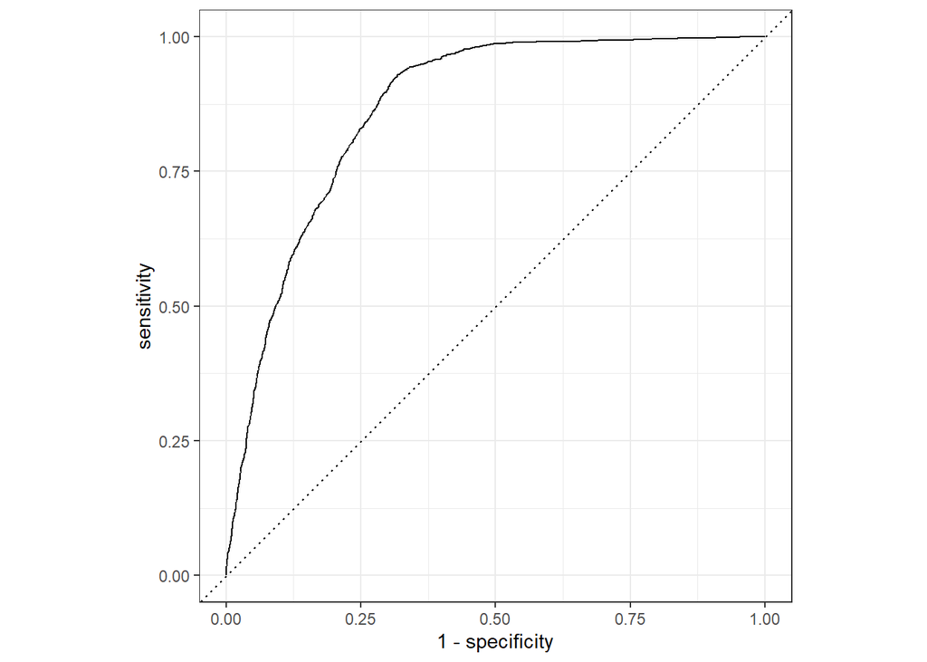

```r
logreg_fit_cv |>
  collect_predictions() |>
  roc_curve(MG_Responded_Desire, .pred_Yes, event_level = "second") |> #ROC of outcome variable and predicted NO
  autoplot()
```

## 16 Random Forest Analysis

Lastly I will run a random forest analysis to evaluate which predictor variables contribute the most to the models predictions.

```r
#remove NAs
preg_desire <- preg_desire |>
  drop_na()

# Model Specification
rf_cls_spec <-
  rand_forest(trees = 1000, min_n = 5) |>
  set_engine("randomForest", importance = TRUE) |>
  set_mode("classification")
rf_cls_spec
```

```
Random Forest Model Specification (classification)

Main Arguments:
  trees = 1000
  min_n = 5

Engine-Specific Arguments:
  importance = TRUE

Computational engine: randomForest
```

```r
# Model Fitting
rf_cls_fit <- rf_cls_spec |>
  fit(MG_Responded_Desire ~ ., data = preg_desire)
rf_cls_fit
```

```
parsnip model object


Call:
 randomForest(x = maybe_data_frame(x), y = y, ntree = ~1000, nodesize = min_rows(~5,      x), importance = ~TRUE)
               Type of random forest: classification
                     Number of trees: 1000
No. of variables tried at each split: 3

        OOB estimate of  error rate: 22.95%
Confusion matrix:
      No  Yes class.error
No  3474 1139   0.2469109
Yes  568 2257   0.2010619
```

```r
# Prediction Values
preg_desire.rf.pred.values <- bind_cols(
  truth = preg_desire$MG_Responded_Desire,
  predict(rf_cls_fit, preg_desire),
  predict(rf_cls_fit, preg_desire, type = "prob")
)

roc_auc(preg_desire.rf.pred.values,
                   truth, .pred_Yes, event_level = "second")
```

```
# A tibble: 1 × 3
  .metric .estimator .estimate
  <chr>   <chr>          <dbl>
1 roc_auc binary         0.871
```

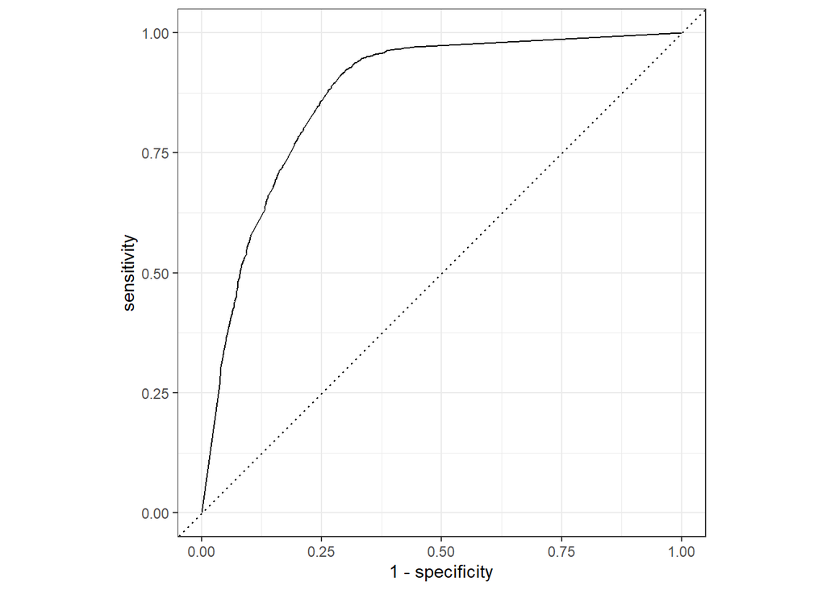

```r
autoplot(roc_curve(preg_desire.rf.pred.values,
                   truth, .pred_Yes, event_level = "second"))
```

To get an understanding of the variables that most contribute to the classification, I will extract the importance scores using the vip package. Using all of the data, first using extract_fit_engine() to get the output from the original function, then using the vip function.

```r
rf_cls_fit |>
  extract_fit_engine() |>
  importance()
```

```
                                 No         Yes MeanDecreaseAccuracy
MF_Race_Cat               5.5112957  47.0782237            50.334612
MF_Age                   19.6692288   2.9486369            24.254945
MF_ethnicity              4.6217182   0.6368091             4.209377
MF_Insurance_Cat         -5.7180909  55.0042327            63.100208
MF_Entry_Obese           -9.3881785   7.0930268            -2.155751
MF_Entry_Encounter_Type   8.1921097  11.8123095            17.388387
HOSPITAL                116.2428246 172.9394421           173.074816
MG_GA                     0.1669317  12.3779782             8.784737
MG_ER_Utilization       -12.4098790  16.4812943            11.566364
                        MeanDecreaseGini
MF_Race_Cat                   299.475152
MF_Age                        109.829359
MF_ethnicity                   11.075199
MF_Insurance_Cat              198.592444
MF_Entry_Obese                 22.973413
MF_Entry_Encounter_Type        48.427335
HOSPITAL                      789.600897
MG_GA                           6.115882
MG_ER_Utilization              34.316711
```

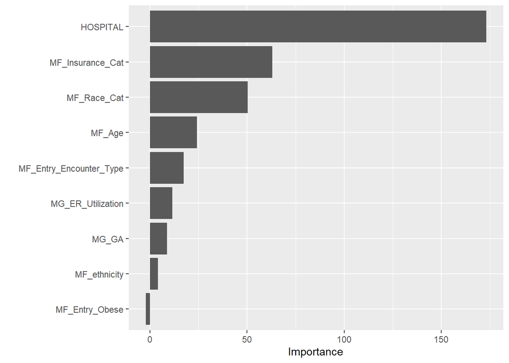

```r
rf_cls_fit |>
  extract_fit_engine() |>
  vip()
```

## 17 Conclusion

In conclusion, the significant influence of hospital location on the likelihood of individuals being asked the pregnancy desire question underscores the complexity of factors contributing to disparities in perinatal care. This project emphasizes the critical need for further investigation into the underlying causes of substantial discrepancies based on patient characteristics between healthcare facilities. Uncovering and addressing potential subconscious bias in the perinatal care setting is crucial for mitigating the observed disparities, particularly for Black women who already face heightened risks in maternal health outcomes. Limitations of the project: The missingness of response in the data creates limitations.

## 18 References

1. Green TL, Zapata JY, Brown HW, Hagiwara N. Rethinking bias to achieve maternal health equity: Changing Organizations, not just individuals. Obstetrics and gynecology. May 1, 2021. Accessed December 13, 2023. https://www.ncbi.nlm.nih.gov/pmc/articles/PMC8055190/.
2. Improving outcomes: Maternal mortality - city of Philadelphia. Accessed December 13, 2023. https://www.phila.gov/media/20210322093837/MMRReport2020-FINAL.pdf.
3. Maternal mortality report finds Non-Hispanic black women represent 73% of pregnancy-related deaths in Philadelphia: Department of Public Health. City of Philadelphia. Accessed December 13, 2023. https://www.phila.gov/2021-03-23-maternal-mortality-report-finds-non-hispanic-black-women-represent-73-of-pregnancy-related-deaths-in-philadelphia/.